# 第九組：結合jiebar與Tidy text套件，處理中文文字資料（Treasure Island）

第九組

2019/04/01

Abstract

情緒分析 Treasure Island

# 系統參數設定

```r
Sys.setlocale(category = "LC_ALL", locale = "zh_TW.UTF-8") # 避免中文亂碼
```

# 書籍下載

- 從 gutenberg 下載 id 為 120 的【Treasure Island】書籍
- 整理書籍成一列一句的資料格式

```r
# 下載 "Treasure Island" 書籍，並且將text欄位為空的行給清除，以及將重複的語句清除 338
red_org <- gutenberg_download(120) %>% filter(text!="") %>% distinct(gutenberg_id, text) %>%
  mutate(linenumber = row_number(),chapter = cumsum(str_detect(text, regex("^[0-9]+$",ignore_case = TRUE))),
         chapter_ind = str_detect(text, regex("^[0-9]+$",ignore_case = TRUE)) |
           lag(str_detect(text, regex("^[0-9]+$",ignore_case = TRUE))))


# 因為 "Treasure Island" 這本書，若直接合併，章節較難尋找，所以這裡的 code 比較迂迴一點
title_data=red_org %>% filter(chapter_ind) %>% select(text) %>% as.matrix() %>%  matrix(byrow = T,ncol = 2) %>% data.frame()
colnames(title_data)=c("chapter","chapter_name")

red_org2<- red_org %>% filter(!chapter_ind & chapter!=0)
split_red_org2=split(red_org2,red_org2$chapter);

n=length(split_red_org2)
red=lapply(1:n, function(i){
  tmp_red_org=split_red_org2[[i]];
  doc = paste0(tmp_red_org$text,collapse = " ") %>% clean()
  #利用 '. ','? '和'! '分成不同句子
  docVector = unlist(strsplit(doc,"\\. |\\? |\\! "), use.names=FALSE)
  red_tmp = data.frame(gutenberg_id = "120" , text = docVector,chapter=i,stringsAsFactors = FALSE) %>% filter(text!="" & text!=" ")
  return(red_tmp)
}) %>% do.call(what = "rbind")%>%
  mutate(linenumber = row_number());
```

# 情緒分析

## Afinn, bing 和 NRC 情緒計算

- 使用 “Afinn”、“bing” 和 “NRC” 情緒辭典分別計算每句的情緒
- Afinn 直接進行相加
- “bing” 和 “NRC” 是使用 ‘positive’ 個數想減 ‘negetive’ 個數

```r
#斷詞
red2=red%>%
  unnest_tokens(word, text)

#計算 "AFinn" 情緒值
afinn <- red2 %>%
  left_join(get_sentiments("afinn")) %>%
  group_by(index = linenumber) %>%
  summarise(sentiment = sum(score,na.rm = T)) %>%
  mutate(method = "AFINN")

#計算"bing" 和 "NRC"情緒值
bing_and_nrc <- bind_rows(red2 %>%
                            left_join(get_sentiments("bing")) %>%
                            mutate(method = "Bing et al."),
                          red2 %>%
                            left_join(get_sentiments("nrc") %>%
                                         filter(sentiment %in% c("positive",
                                                                 "negative"))) %>%
                            mutate(method = "NRC"))%>%
  count(method, index = linenumber, sentiment)%>%
  spread(sentiment, n, fill = 0) %>%
  mutate(sentiment = positive - negative)%>% select(index,sentiment,method)


red3=bind_rows(afinn,
          bing_and_nrc)  %>% spread(method,sentiment) %>% select(index,AFINN,`Bing et al.`,NRC)
```

## 使用CoreNLP 計算情緒

### API呼叫的設定

server端 : + 需先在terminal開啟corenlp server + 在corenlp的路徑下開啟terminal輸入 `java -mx4g -cp "*" edu.stanford.nlp.pipeline.StanfordCoreNLPServer -port 9000 -timeout 15000`

```r
# 生產core-nlp的api url，可以設定斷詞依據、以及要標註的任務
generate_API_url <- function(host, port="9000",
                             tokenize.whitespace="false", annotators=""){ #斷詞依據不是空格
  url <- sprintf('http://%s:%s/?properties={"tokenize.whitespace":"%s","annotators":"%s"}',
                 host, port, tokenize.whitespace, annotators)
  url <- URLencode(url)
}
generate_API_url("127.0.0.1")

host = "127.0.0.1"
source("sentiment_function.R")
```

### coreNLP 服務分析句子

#### 將句子丟入服務

取得coreNLP回傳的物件

```r
load("coreNLP_HW_0330_all_120.RData")
# gc() #釋放不使用的記憶體
#
# t0 = Sys.time()
# #all
# obj = red[,c(3,4,2)]  %>% filter(text != "") %>% coreNLP(host)
#
#
# #先過濾掉沒有內容的的tweet
# #丟入coreNLP的物件 必須符合: 是一個data.frame 且有一個text欄位
#
# Sys.time() - t0 #執行時間
# #Time difference of 17.89611 mins
#
# save.image("coreNLP_HW_0330_all_120.RData")
```

- 利用 coreNLP 計算句子情緒
- 與 “AFinn”、“bing” 和 “NRC” 的情緒值合併
- 將情緒值轉換成 -1,0,1 負面，無情緒與正面，並計算重疊率

```r
char2num<-function(x){
  x %>% as.character %>% as.numeric()
}
sentiment = coreNLP_sentiment_parser(obj)
sentiment=sentiment %>% mutate(linenumber=char2num(linenumber),chapter=char2num(chapter),sentimentValue=(char2num(sentimentValue)-2))

red8=red3 %>% left_join(sentiment,c("index"="linenumber"))

#將情緒值轉換成 -1,0,1
red8_sign=red8 %>% select(AFINN,`Bing et al.`,NRC,sentimentValue) %>% mutate_all(sign)
#計算重疊率
sapply(red8_sign, function(x) sapply(red8_sign, function(y) mean(x==y))) %>% print
```

[output not shown]

```r
tmp=(table(red8_sign$sentimentValue,red8_sign$`Bing et al.`)/nrow(red8_sign))
rownames(tmp)=paste("corenlp",c("負","中","正"))
colnames(tmp)=paste("bing",c("負","中","正"))
tmp
```

```r
red_tmp=red8 %>% filter(sign(sentimentValue)==-1,sign(`Bing et al.`)==1)
red_tmp %>% head(10) %>% kable
```

- 以每 80 局分別計算情緒值，並以 barplot 顯示

```r
red9=red8 %>% group_by(index_line80=index%/%80) %>% summarise_each(funs(mean),-index,-chapter,-sentiment,-text)

red10=red9%>% gather(method,sentiment,-index_line80)

#cor(red9 %>% select(-index_line80)) %>% print

#若要轉換成是以 chapter 是用這個 code
# red10=red8 %>% group_by(index_line80=chapter) %>% summarise_each(funs(mean),-index,-chapter,-sentiment,-text) %>% gather(method,sentiment,-index_line80)

red10%>%
  ggplot(aes(index_line80, sentiment, fill = method)) +
  geom_col(show.legend = FALSE) +
  facet_wrap(~method, ncol = 1, scales = "free_y")
```

[output not shown]

```r
par(mfrow=c(1,1))
red_len=red8 %>% mutate(sentense_len=lengths(gregexpr("\\W+", text)) + 1)
m1=aov(log(sentense_len)~factor(sentimentValue),data=red_len)
summary(m1)
plot(red_len$sentimentValue %>% as.factor(),red_len$sentense_len,xlab="情緒值",ylab="字數")
```

[output not shown]

- 比較“corenlp” 判斷為正面句子中的詞彙比率與判斷為負面句子中的詞彙比率
- 詞彙大小是以比率差異，即差異越大，詞彙就越大
- 紅色為詞彙在正面句子出現比率大於負面句子出現比率，黑色則相反

[interactive chart not shown]

#### 從回傳的物件中提取斷詞、詞彙還原、詞性標註、命名實體標註等結果

##### tokens

```r
tokens =  coreNLP_tokens_parser(obj)
tokens %>% head
```

coreNLP_tokens_parser欄位:

- status_id : 對應原本df裡的status_id，為一則tweets的唯一id
- word: 原始斷詞
- lemma : 對斷詞做詞形還原
- pos : part-of-speech,詞性
- ner: 命名實體

#### 從NER查看特定類型的實體

```r
tokens$lower_word = tolower(tokens$word)
tokens$lower_lemma = tolower(tokens$lemma)
```

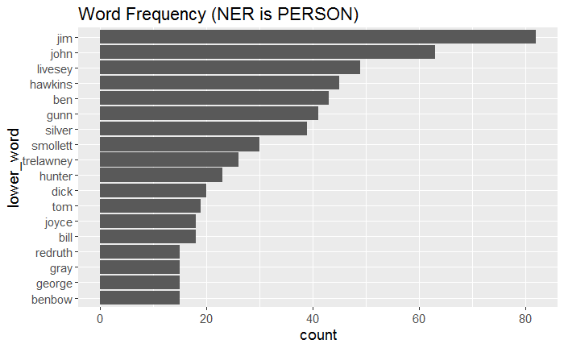

```r
tokens %>%
  filter(ner == "PERSON") %>%  #篩選NER為PERSION
  group_by(lower_word) %>% #根據word分組
  summarize(count = n()) %>% #計算每組
  top_n(n = 15, count) %>%
  ungroup() %>%
  mutate(lower_word = reorder(lower_word, count)) %>%
  ggplot(aes(lower_word, count)) +
  geom_col()+
  ggtitle("Word Frequency (NER is PERSON)") +
  theme(text=element_text(size=14))+
  coord_flip()
```

```r
tokens %>%
  filter(ner == "COUNTRY") %>%  #篩選NER為COUNTRY
  group_by(lower_word) %>% #根據word分組
  summarize(count = n()) %>% #計算每組
  top_n(n = 10, count) %>%
  ungroup() %>%
  mutate(lower_word = reorder(lower_word, count)) %>%
  ggplot(aes(lower_word, count)) +
  geom_col()+
  ggtitle("Word Frequency (NER is COUNTRY)") +
  theme(text=element_text(size=14))+
  coord_flip()
```

[output not shown]

```r
tokens %>%
  anti_join(stop_words,by = c("lower_lemma"="word")) %>%
  filter(str_detect(lower_lemma, regex("^[a-z].*$",ignore_case = TRUE)))%>%
  group_by(lower_lemma) %>%
  summarise(count = n()) %>%
  top_n(n = 20, count) %>%
  arrange(desc(count)) %>% kable
```

[output not shown]